# Cross-cohort Bulk RNA-seq Analysis: Differential expression and functional enrichment

Davide Maccarrone 2026-09-03

# Executive Summary

This report describes the differential expression and comparative transcriptomic analysis a primary analysis cohort and a sensitivity analysis cohort derived from GSE193677, where the `primary_cohort` represent a subset with sample from Ileum not inflammed, and the `sensitivity_cohort` it’s a mix of sample inflammed and not.

The objective of this analysis was to characterize the CD-associated transcriptional signature within each cohort and compare the results from GSEA to the findings of the other analysis of the project.

The analytical workflow included:

- platform-specific quality control and exploratory data analysis
- differential expression analysis using statistical models to obtain DEGs (limma-voom)
- functional enrichment through Over-Representation Analysis (ORA) and Gene Set Enrichment Analysis (GSEA)

Across the two cohorts, a consistent core of dysregulated genes and biological pathways was identified, supporting the reproducibility of the CD transcriptional phenotype across bulk RNA-seq and not only single cell RNA-seq.

# Dataset Overview

| Dataset | Platform | Controls | CD Samples | Cell Population | Reference |
| --- | --- | --- | --- | --- | --- |
| GSE193677 - Primary analysis | GPL16791 Illumina HiSeq 2500 | 121 | 201 | Intestinal biopsy tissue |  |
| GSE193677 - Sensitivity analysis | GPL16791 Illumina HiSeq 2500 | 121 | 351 | Intestinal biopsy tissue |  |

# Analytical Workflow

The analytical pipeline was implemented independently for each cohort, using platform-appropriate statistical methodology, and integrated only at the level of summary statistics and enrichment results.

1. Raw data import and sample-metadata alignment
2. Quality control and exploratory data analysis (PCA, sample-to-sample distance and correlation heatmaps, outlier detection)
3. Differential expression analysis
   - limma-voom (empirical Bayes, `voomlmFit` → `makeContrasts` → `eBayes`)
4. Multiple testing correction (Benjamini-Hochberg)
5. Functional enrichment analysis
   - ORA against GO, KEGG, Reactome, and MSigDB Hallmark collections
   - GSEA using pre-ranked, transcriptome-wide statistics (`fgsea`)
6. Cross-cohort comparison
   - correlation of differential expression statistics across shared genes
   - concordance of enrichment results (NES) across datasets

# Quality Control and Exploratory Data Analysis

Sample-level quality control was performed independently for each cohort prior to differential expression analysis. As expected given the whole-biopsy nature of the tissue and the exclusion of overtly inflamed samples in the primary cohort, PC1-PC2 do not show a sharp separation between CD and Control - consistent with a subtle, compositionally diluted disease signal rather than a dominant single axis of variation.

## Primary cohort

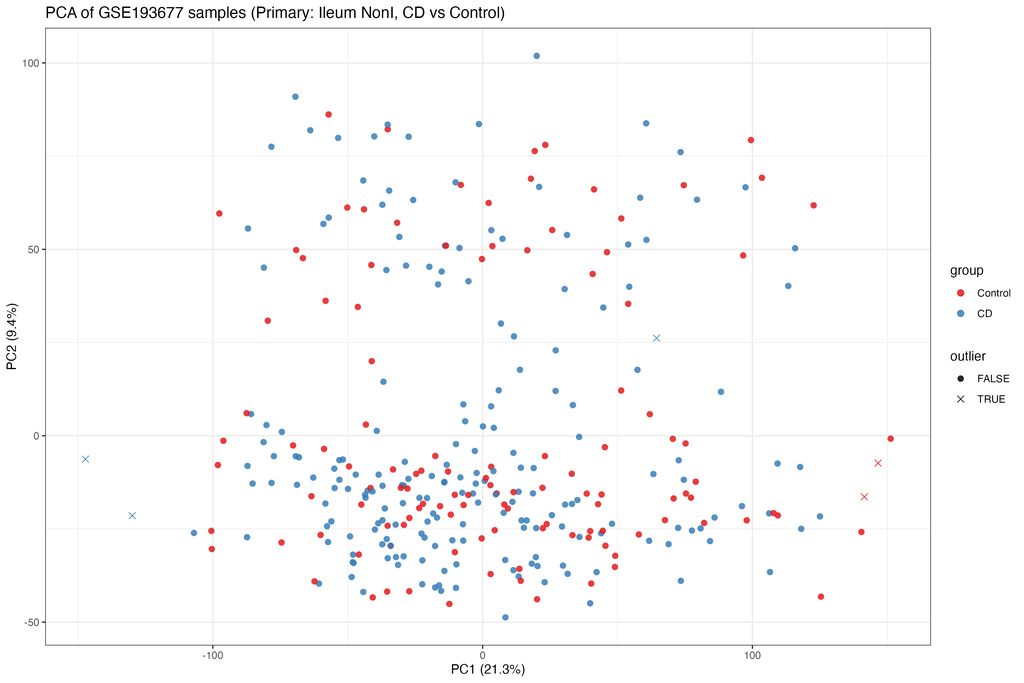

## Sensitivity cohort

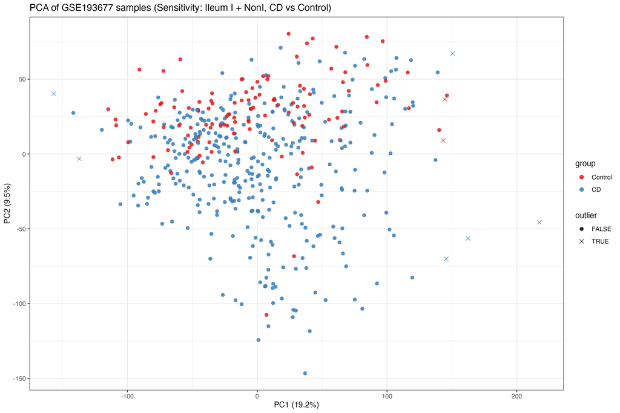

# Differential Expression Analysis

Differential expression was assessed independently for each cohort using the limma-voom statistical model, comparing CD patients versus healthy controls. Significance thresholds were defined as:

- Adjusted p-value (Benjamini–Hochberg) < 0.05
- Absolute log2 fold-change > 1

## Summary of differentially expressed genes

| Cohort | Total genes tested | DEG (up) | DEG (down) | Total DEG |
| --- | --- | --- | --- | --- |
| Primary | 20975 | 23 | 54 | 77 |
| Sensitivity | 21856 | 127 | 95 | 222 |

**Primary Cohort**

## Volcano plot

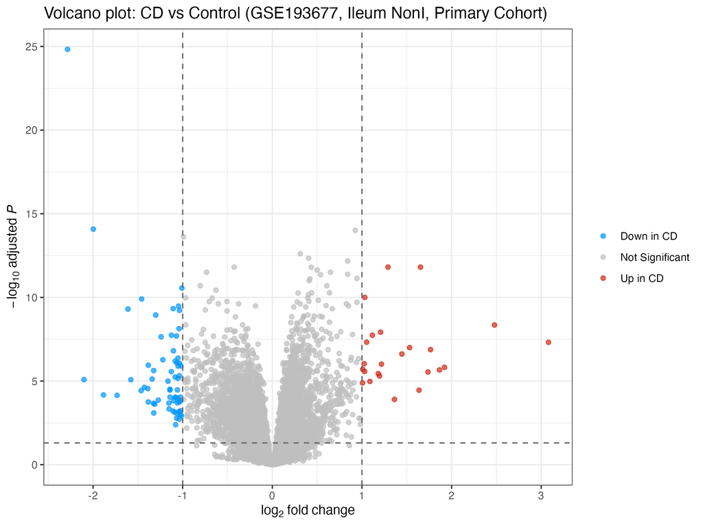

## Heatmap

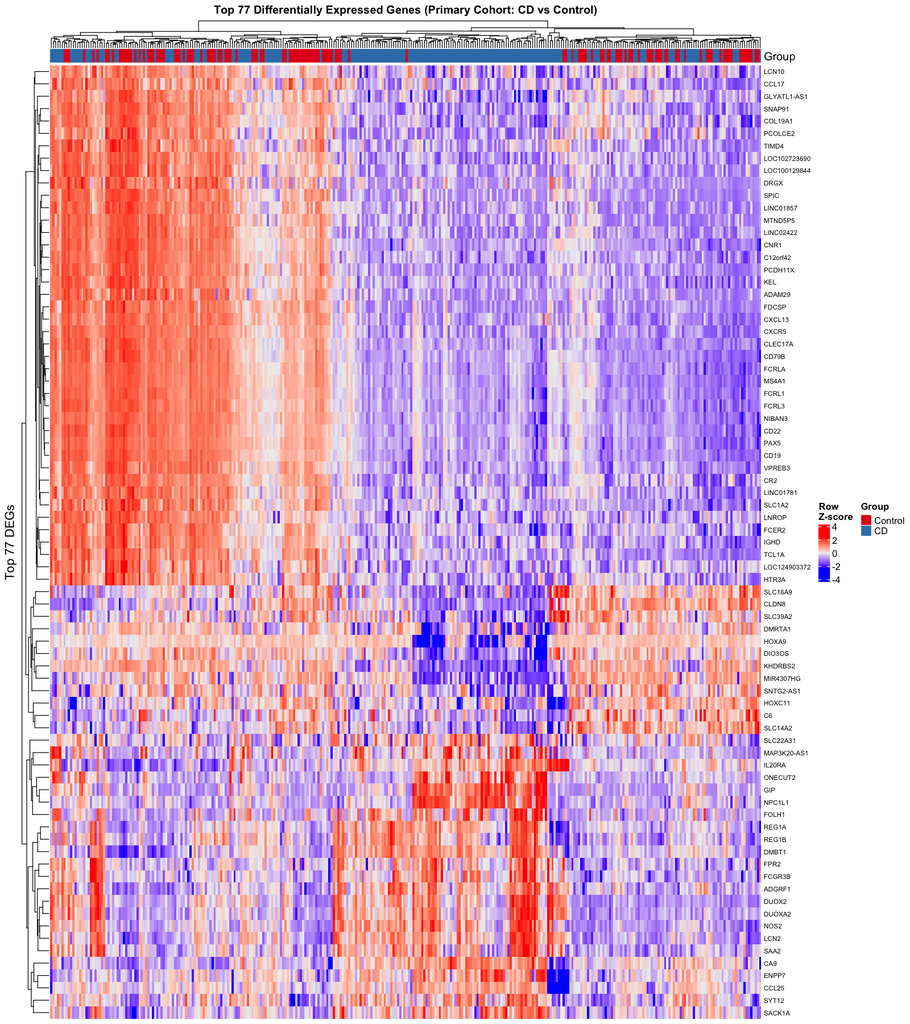

## Biological interpretation

The primary analysis identified 77 differentially expressed genes, with a predominance of downregulated genes in Crohn’s disease. The heatmap shows a partial but directionally consistent separation between CD and Control samples, indicating that the identified DEGs capture a disease-associated component of the transcriptional phenotype, although not a dominant axis of global sample variance (consistent with the diffuse PCA structure noted above).

**Sensitivity Cohort**

## Volcano plot

[figure not shown]

## Heatmap

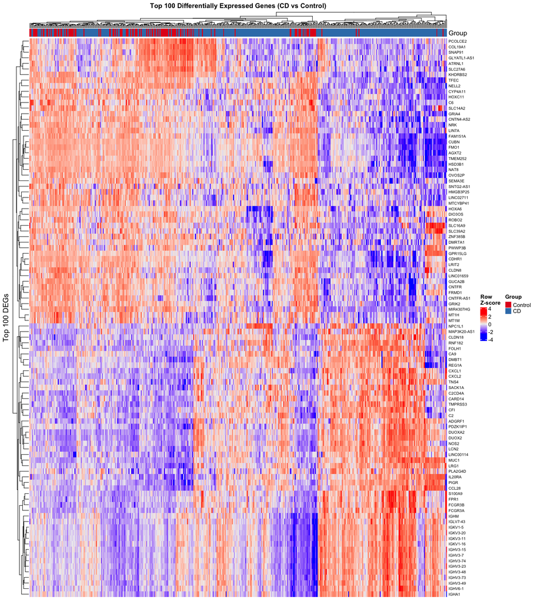

## Biological interpretation

The sensitivity analysis identified a broader transcriptional signature, with 222 differentially expressed genes compared with 77 genes in the primary analysis. The increased number of significant genes is consistent with the larger CD sample size and therefore greater statistical power, while the inclusion of both inflamed and non-inflamed biopsies also introduces additional biological heterogeneity.

# Over-representation analysis (ORA)

**Primary Cohort**

## GO Terms

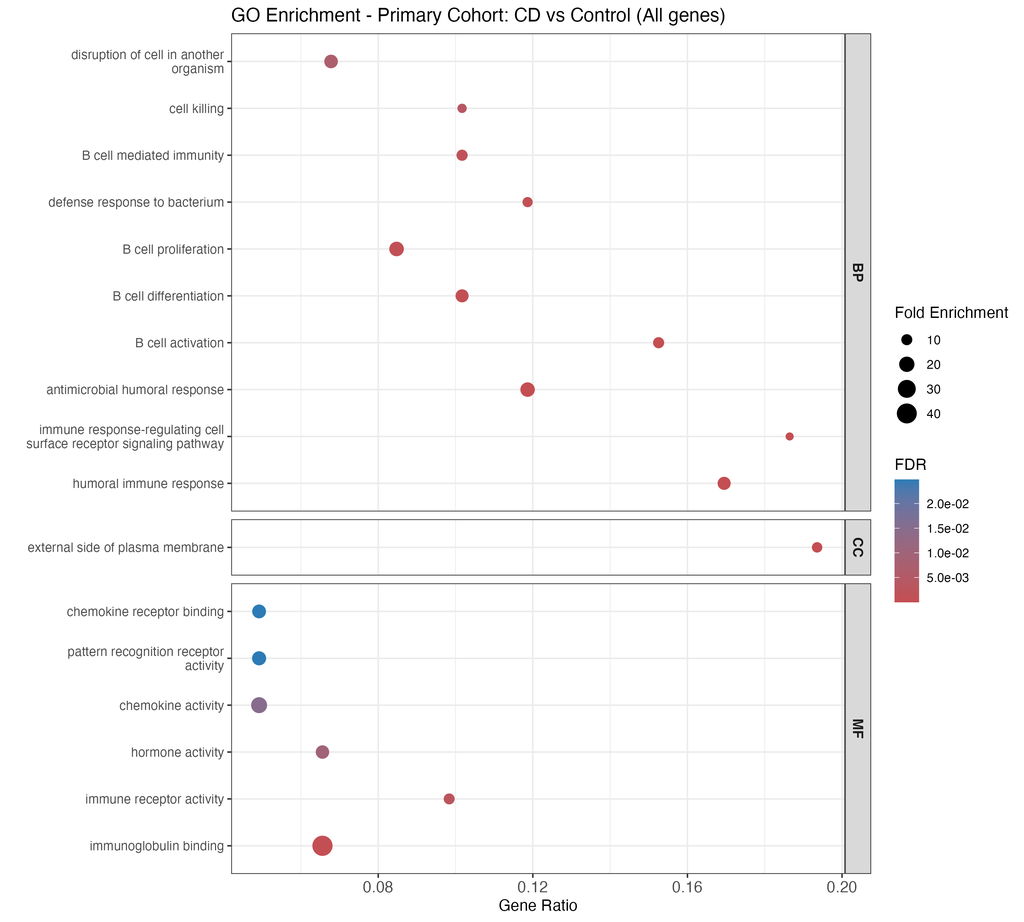

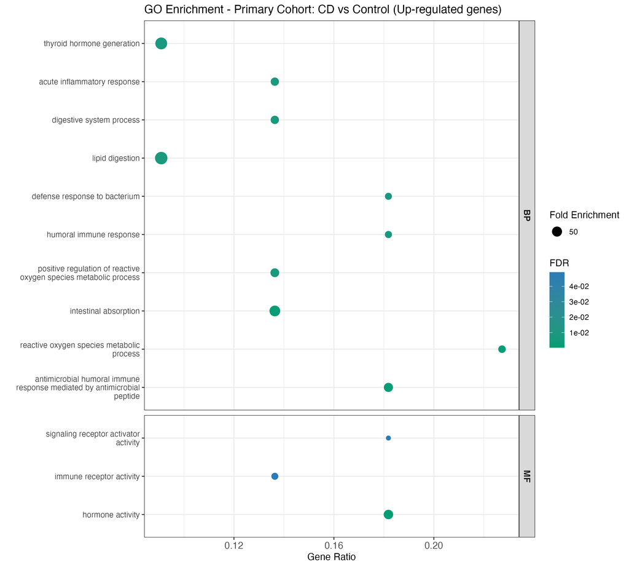

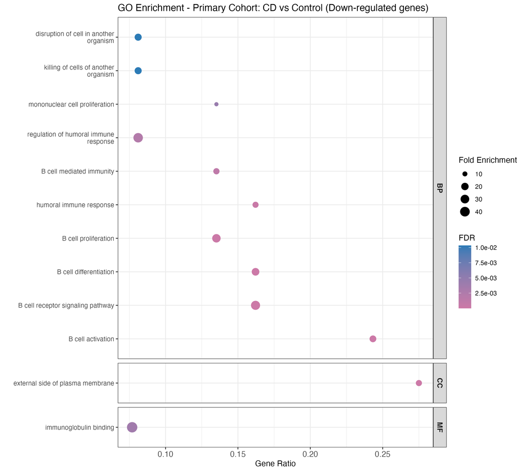

## Reactome

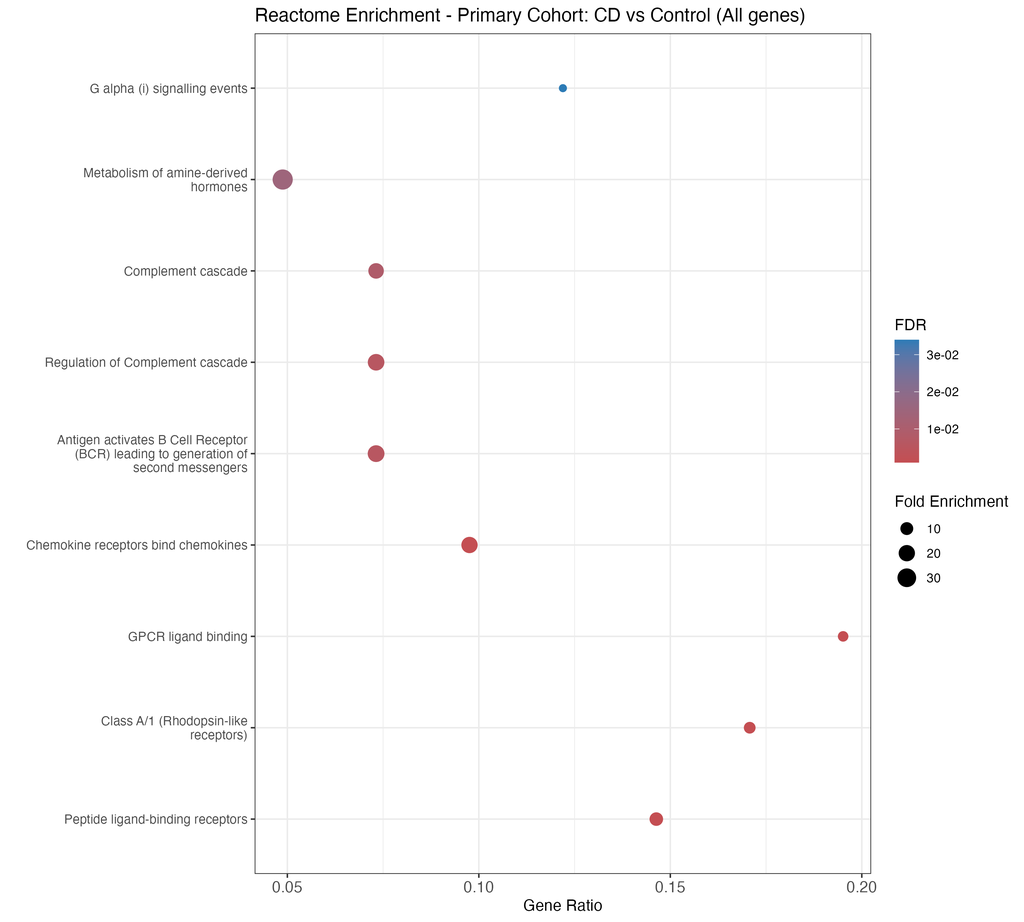

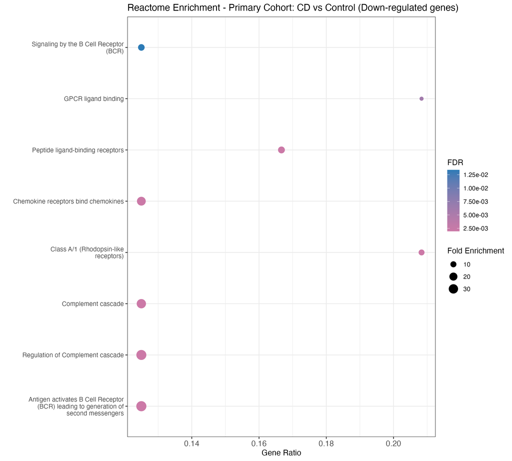

### Treeplots

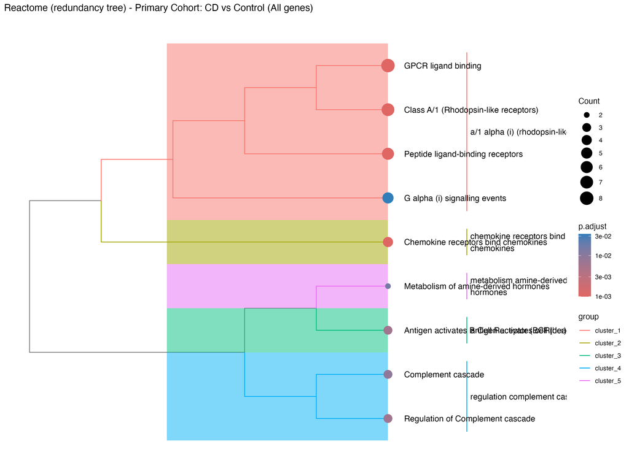

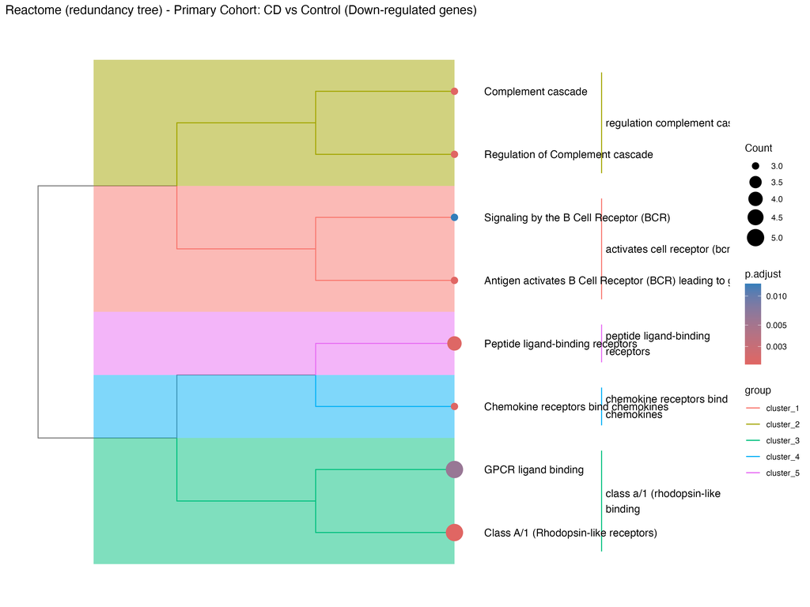

## KEGG

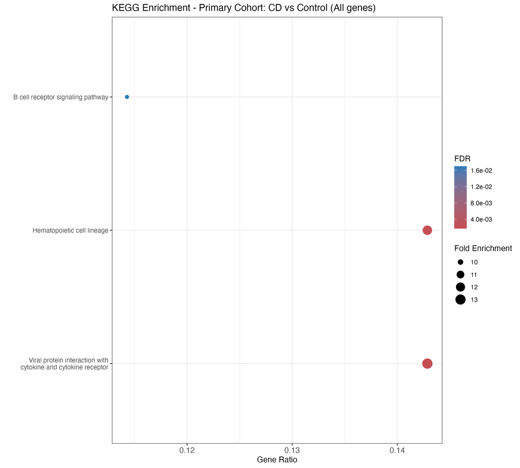

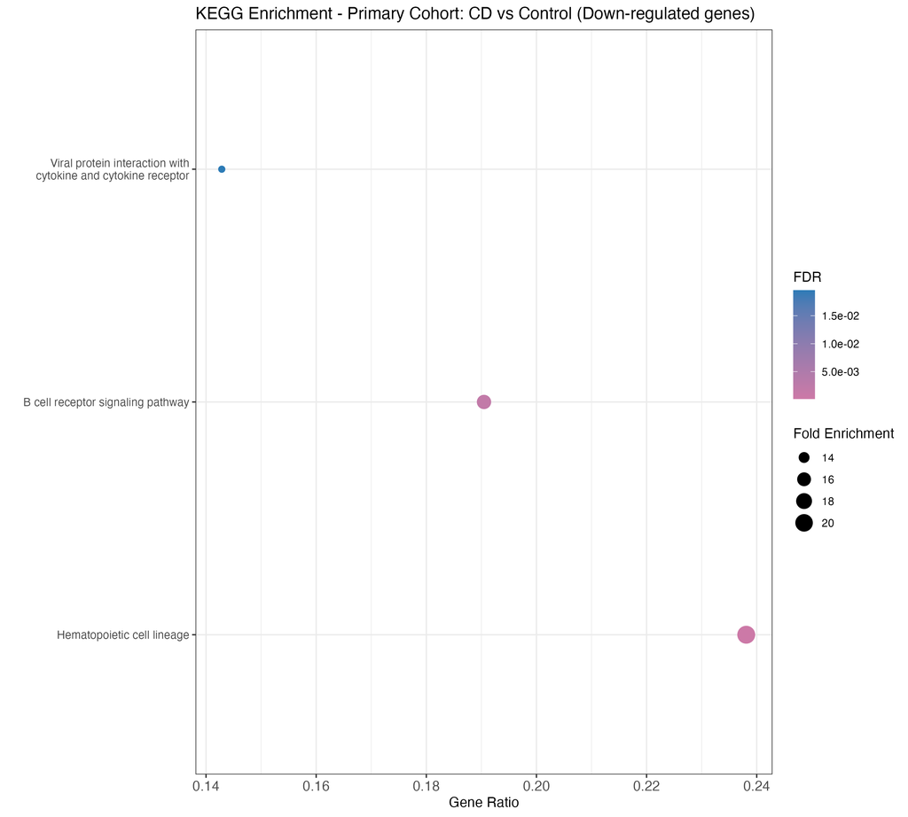

### Treeplots

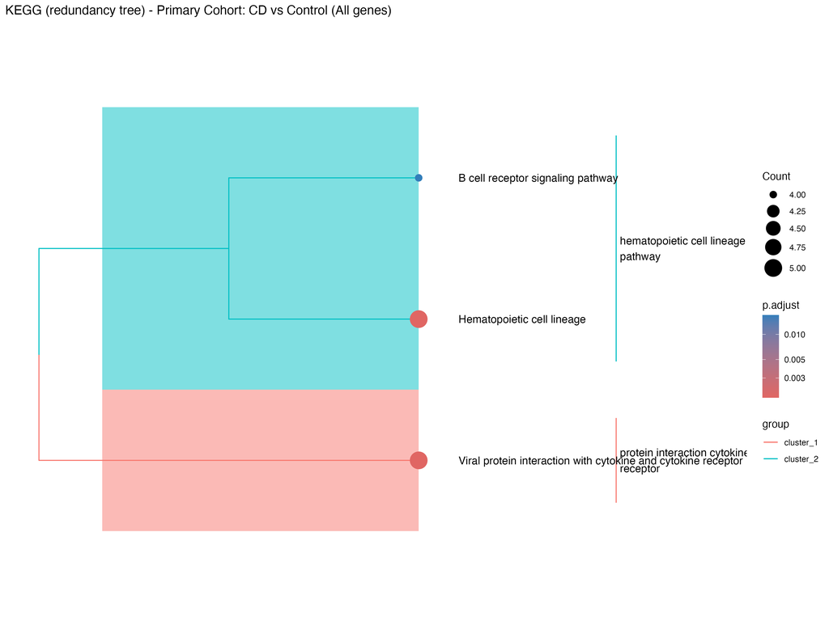

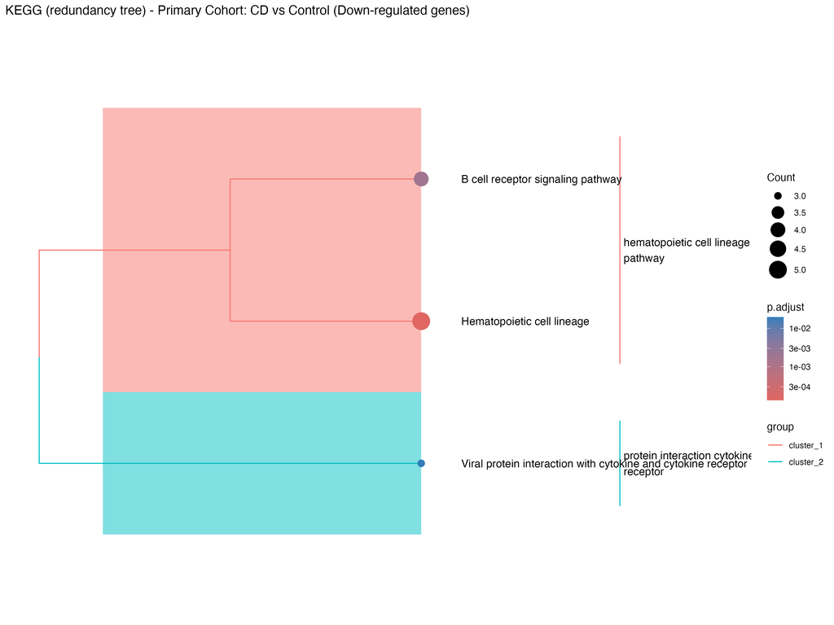

## ORA enrichment results empty for primary cohort

| Analysis | Result |
| --- | --- |
| Reactome – Upregulated genes | *Metabolism of amine-derived hormones* |
| Hallmark – Upregulated genes | *Xenobiotic metabolism* |
| Hallmark – All genes | No significant enrichment |
| Hallmark – Downregulated genes | No significant enrichment |
| KEGG – Upregulated genes | No significant enrichment |

## Biological interpretation

Beyond the B-cell/complement signal already described above, ORA against the remaining Reactome, Hallmark and KEGG subsets (upregulated- and all-gene queries) produced limited additional significant enrichment, reflecting the relatively small number of DEGs available for over-representation testing in these specific queries. The only significant Hallmark result among the upregulated genes was Xenobiotic Metabolism, while Reactome identified Metabolism of Amine-Derived Hormones. No significant enrichment was detected for the remaining tested gene sets. These results should therefore be considered supportive rather than central to the biological interpretation of the primary cohort. The limited ORA signal is also consistent with the substantially richer pathway-level information obtained using the transcriptome-wide GSEA approach.

**Sensitivity Cohort**

## GO Terms

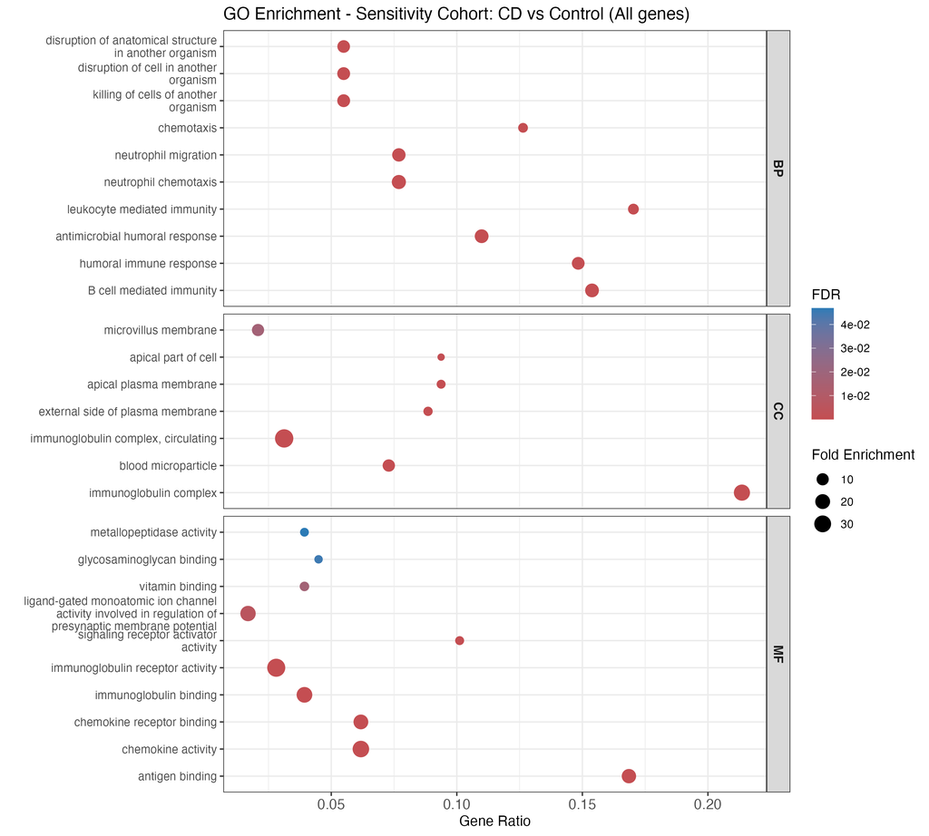

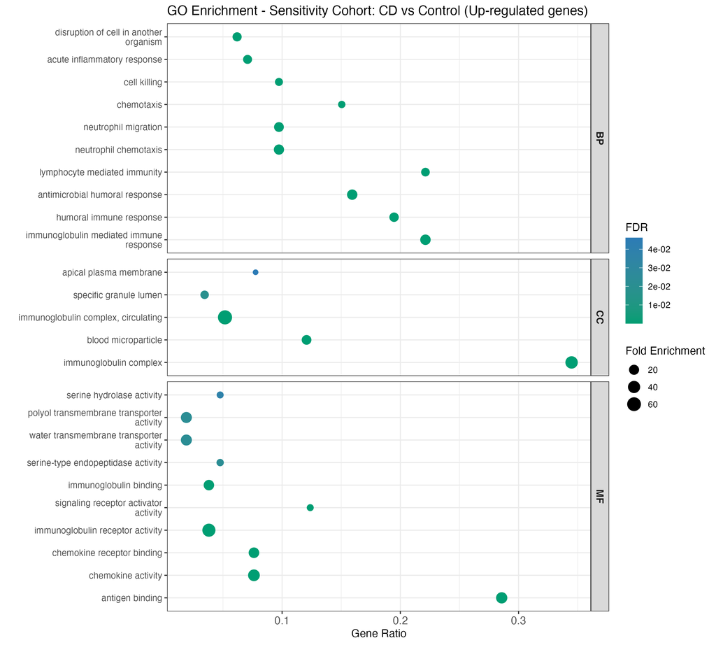

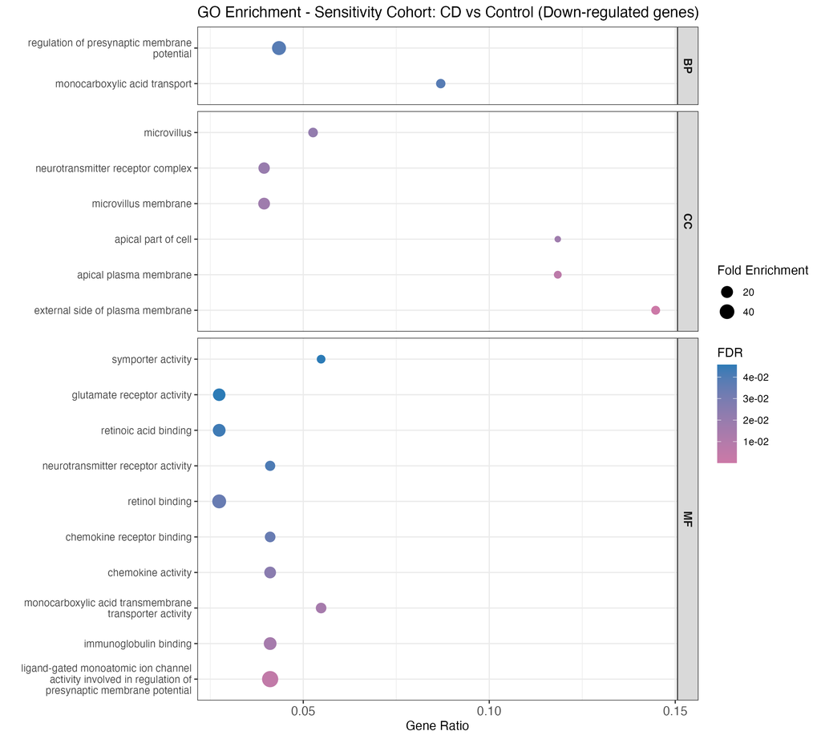

## Reactome

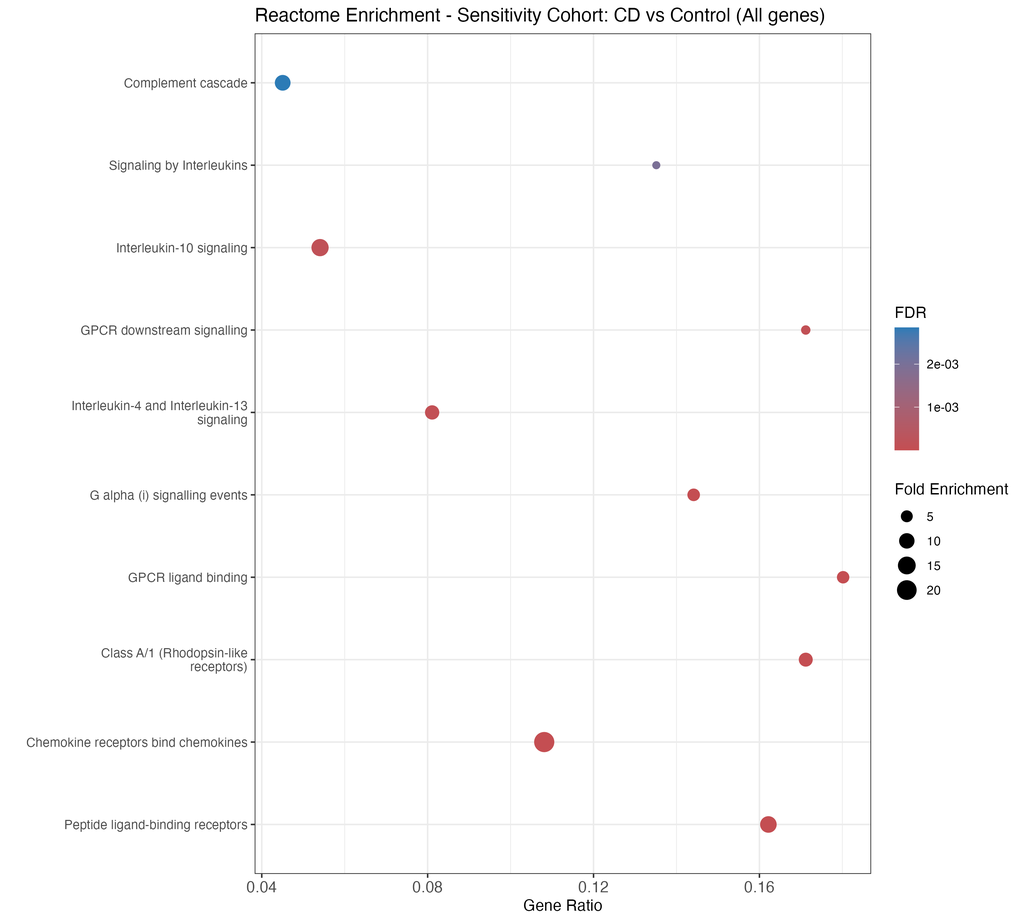

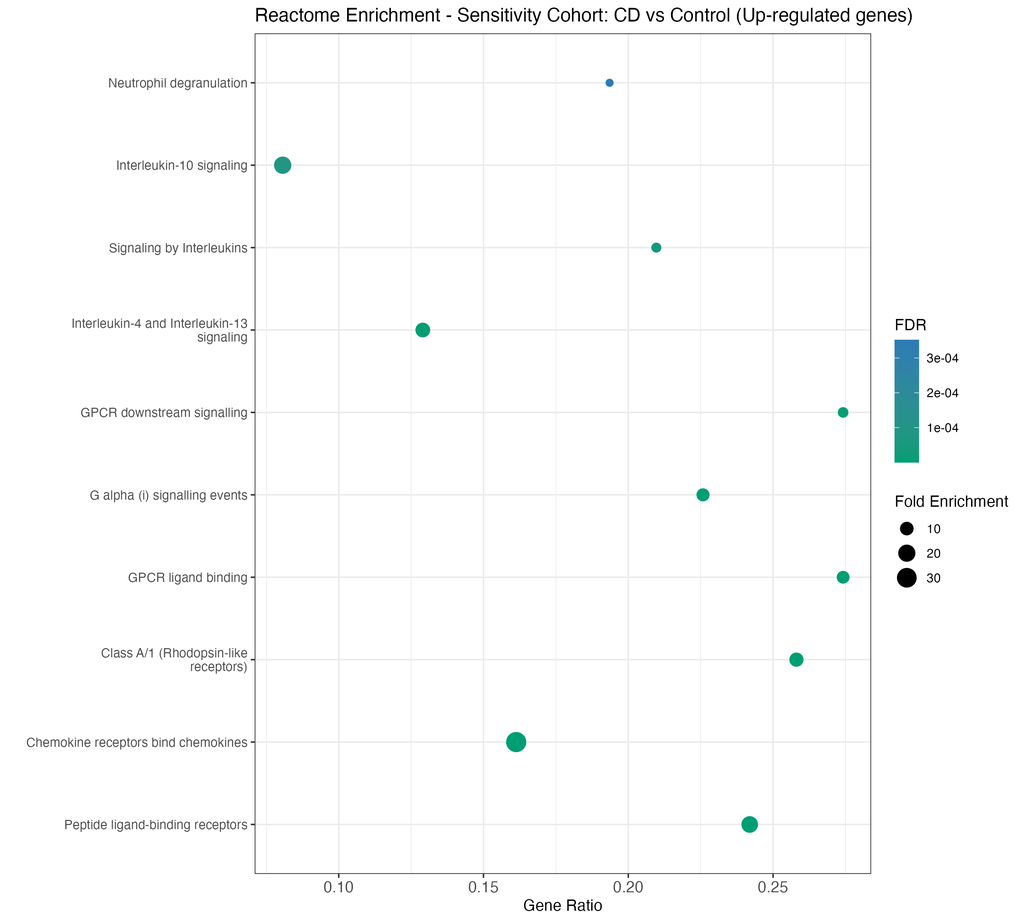

### Treeplots

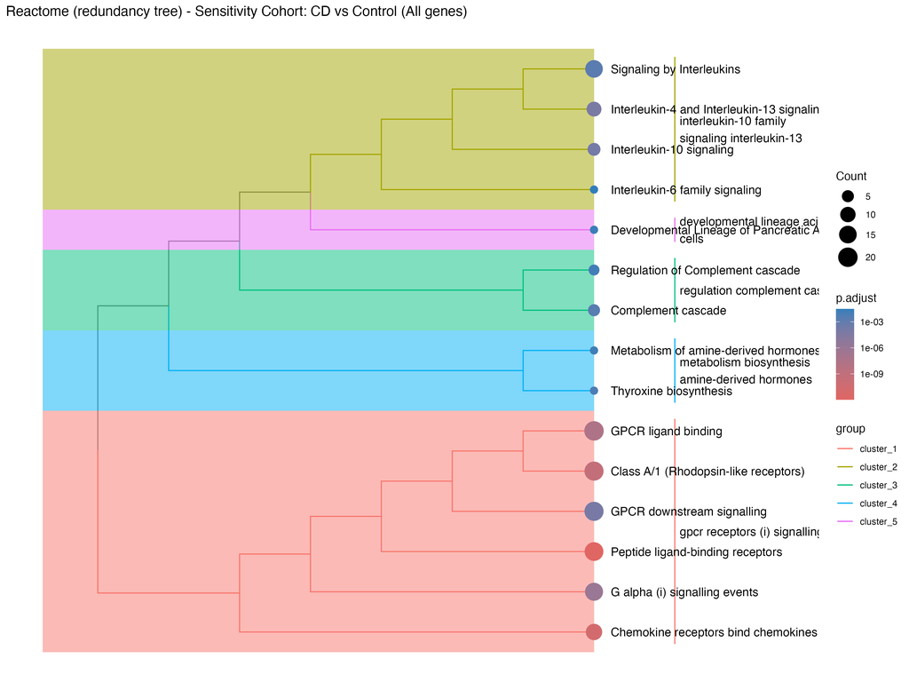

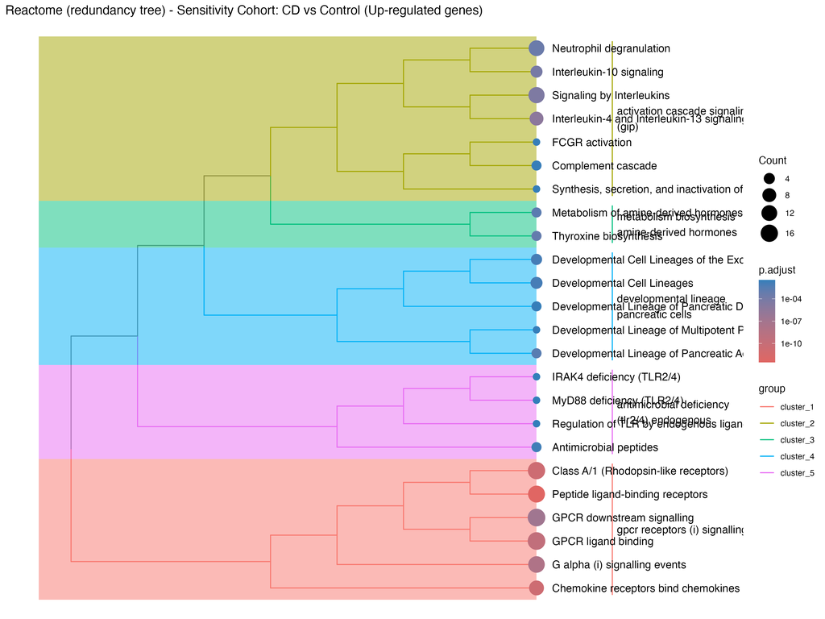

## KEGG

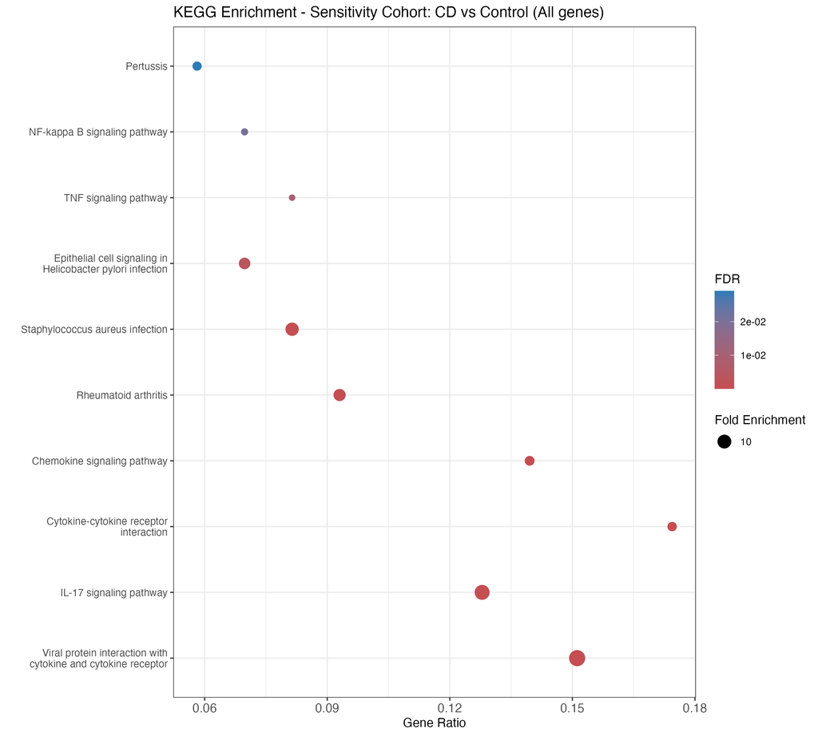

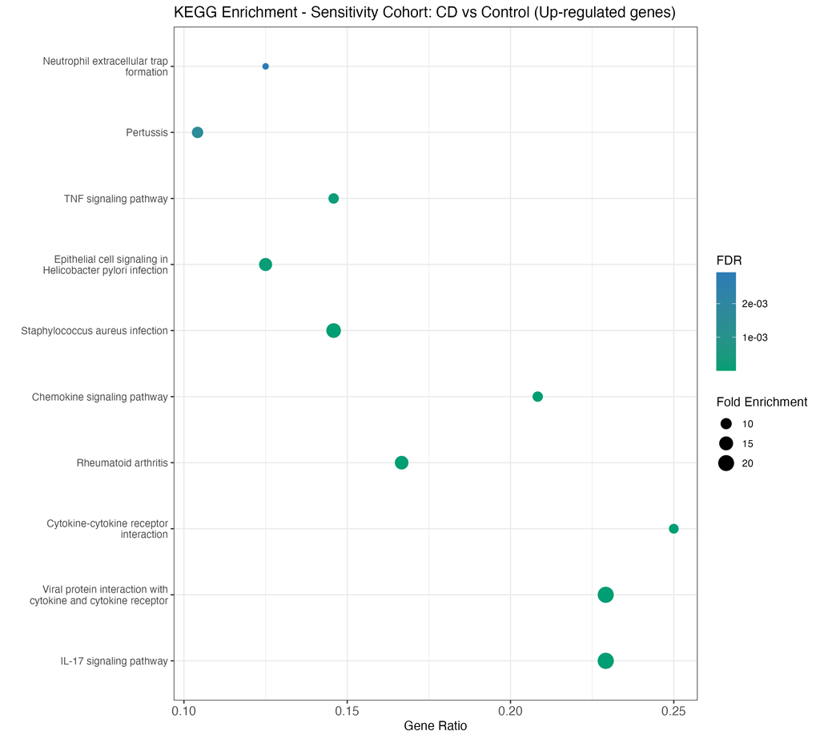

### Treeplots

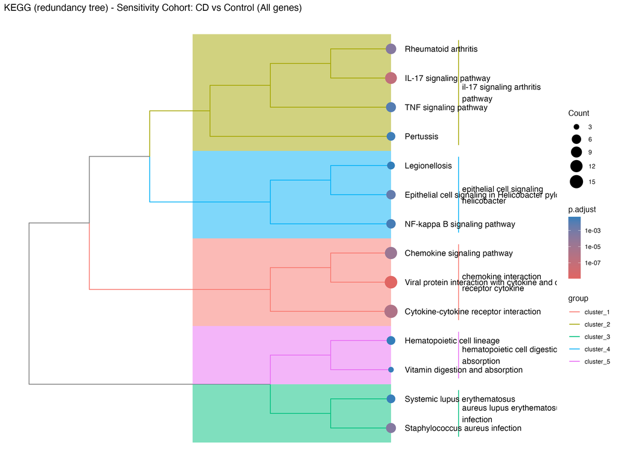

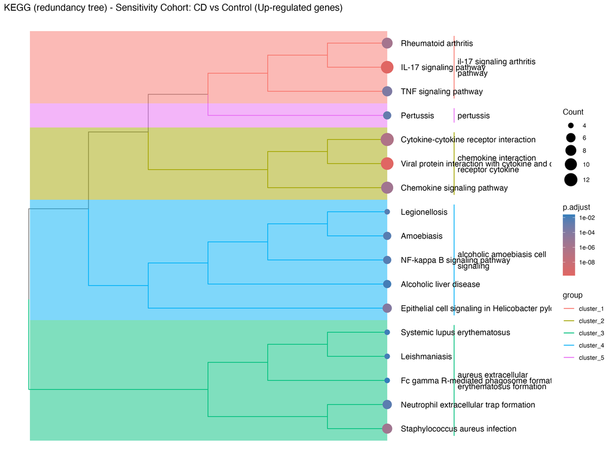

## Hallmarks Collection H

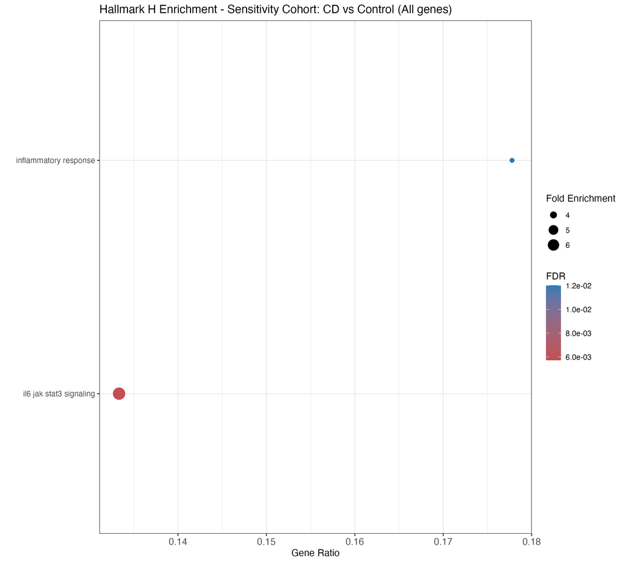

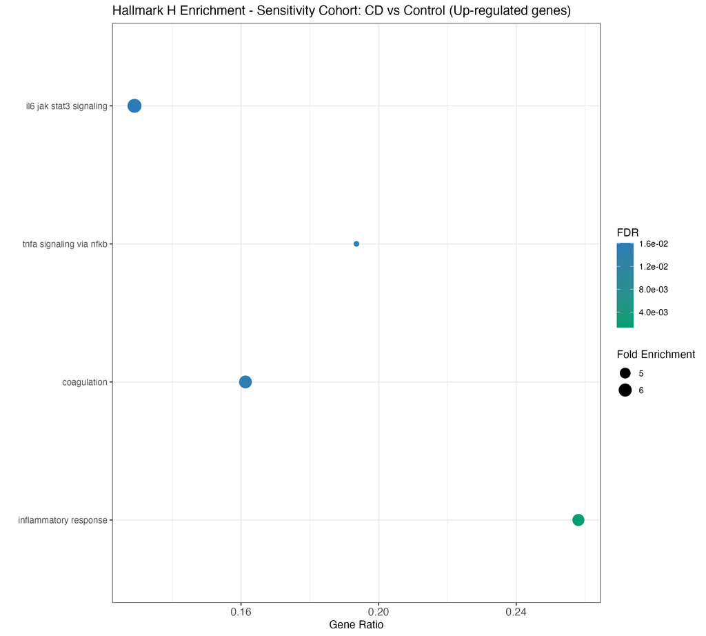